# Impact of Right Heart Catheterization on 30-Day Mortality in Critically Ill Patients: An Observational Cohort Study

A Propensity Score Approach to Mitigate Selection Bias

Abderrezzaq KADOUCHE

## **Introduction**

Right Heart Catheterization is an invasive diagnostic procedure used to directly measure cardiac function in critically ill patients. In an ideal world, the efficacy of such procedures would be tested via Randomized Controlled Trials. However, in critical care settings, withholding or applying treatment at random is often unethical or logistically impossible. Ultimately, this study provides the ultimate playground for validating and comparing causal inference methodologies in a real-world setting.

## **Objective**

The primary objective of this project is to rigorously estimate the causal impact of Right Heart Catheterization (RHC) on 30-day patient survival rates.

## **Study Design and Data**

This case study leverages observational data from the SUPPORT cohort study, focusing on patients admitted to intensive care units. Because treatment assignment was non-randomized, the study design mirrors a quasi-experimental framework where confounding variables must be statistically adjusted to isolate the true causal effect of the intervention.

The analytics dataset consists of the following key structures:

**• Sample Profile:** A total of n = 5735 critically ill patients, split into a treatment group of 2184 individuals who received RHC and a control group of 3551 individuals.

**• Temporal Windows:** The treatment variable evaluates whether RHC was performed within the critical 24-hour window following hospital admission.

**• Outcome :** The primary clinical endpoint is a binary indicator tracking 30-day post-admission survival (1 if survived, 0 if deceased).

## **Variable Specifications** (CDISC SDTM Alignment)

The dataset encompasses **74 variables**, mapping directly to standard CDISC SDTM domains. All covariates are categorized into their respective CDISC domains :

### Core Protocol Variables

- **Treatment (Intervention - PR Domain):** `swang1` → Mapped to **PRTRT** (Procedure Name). A binary indicator tracking whether Right Heart Catheterization (Procedure) was performed within 24 hours of ICU admission.
- **Outcome (Disposition - DS Domain):** `death` → Mapped to **DSTERM / DSDECOD** (Disposition Event: Death). A binary endpoint capturing 30-day post-admission mortality status.

### Baseline Covariates Mapping (72 Variables across SDTM Domains)

| CDISC SDTM Domain | Domain Code | Description & Dataset Variables | Count |
| --- | --- | --- | --- |
| **Demographics** | **DM** | Key baseline characteristics including Age (`age`), Sex (`sex`), Race (`race`), income, and insurance categories. | 6 |
| **Medical History** | **MH** | Pre-existing conditions and comorbidities recorded at baseline (e.g., historical cardiovascular disease, renal failure, or malignancies). | 12 |
| **Vital Signs** | **VS** | Objective physiological measures tracked during the initial 24 hours: body temperature, mean blood pressure, and heart rate. | 5 |
| **Laboratory Results** | **LB** | Extensive blood chemistry and hematology profile: serum electrolytes (sodium, potassium), pH, PaO₂/FiO₂ ratio, bilirubin, albumin, and white blood cell (WBC) count. | 30 |
| **Subject Questionnaires & Clinical Scales** | **QS / FT** | Derived scoring indexes measuring acute severity and baseline neurological function: APACHE III score, Glasgow Coma Scale (GCS), and ADL indexes. | 10 |
| **Inclusion / Exclusion Criteria** | **IE** | Primary diagnostic categories defining critical care admission eligibility (e.g., Acute Respiratory Failure, COPD, CHF, Cirrhosis, Coma, or Sepsis). | 9 |

## **Descriptive analysis of continuous variables**

```r
library(prettyR)



# Extraire  les variables numériques
vars_quanti <- names(data)[sapply(data, is.numeric)]

# Description des variables quantitatives
describe(
  data[, vars_quanti],
  num.desc = c("min", "max", "mean", "median", "sd", "valid.n")
)
```

```
## Description of data[, vars_quanti]
```

```
##
##  Numeric
##             min    max   mean median     sd valid.n
## age       18.04 101.85  61.38  64.05  16.68    5735
## edu        0.00  30.00  11.68  12.00   3.15    5735
## das2d3pc  11.00  33.00  20.50  19.75   5.32    5735
## surv2md1   0.00   0.96   0.59   0.63   0.20    5735
## aps1       3.00 147.00  54.67  54.00  19.96    5735
## scoma1     0.00 100.00  21.00   0.00  30.27    5735
## wtkilo1    0.00 244.00  67.83  70.00  29.06    5735
## temp1     27.00  43.00  37.62  38.09   1.77    5735
## meanbp1    0.00 259.00  78.52  63.00  38.05    5735
## resp1      0.00 100.00  28.09  30.00  14.08    5735
## hrt1       0.00 250.00 115.18 124.00  41.24    5735
## pafi1     11.60 937.50 222.27 202.50 114.95    5735
## paco21     1.00 156.00  38.75  37.00  13.18    5735
## ph1        6.58   7.77   7.39   7.40   0.11    5735
## wblc1      0.00 192.00  15.65  14.10  11.87    5735
## hema1      2.00  66.19  31.87  30.00   8.36    5735
## sod1     101.00 178.00 136.77 136.00   7.66    5735
## pot1       1.10  11.90   4.07   3.80   1.03    5735
## crea1      0.10  25.10   2.13   1.50   2.05    5735
## bili1      0.10  58.20   2.27   1.01   4.80    5735
## alb1       0.30  29.00   3.09   3.50   0.78    5735
```

# **Data Management**

Prior to statistical analysis, a systematic data cleaning process was conducted to identify implausible or erroneous values. For each continuous variable, the ten lowest and ten highest observations were inspected.

Values of zero for weight (wtkilo1), mean arterial pressure (meanbp1), respiratory rate (resp1), heart rate (hrt1), and white blood cell count (wblc1) were considered biologically implausible and were therefore replaced by missing values (NA).

For albumin (alb1), implausibly high values (11.0 and 29.0 g/dL) were deemed to be data entry errors and were treated accordingly.

In contrast, extreme values for temperature (temp1), pH (ph1), PaO2/FiO2 ratio (pafi1), and Glasgow Coma Scale (scoma1) were judged to be clinically plausible in the intensive care setting and were retained.

After cleaning, all variables were checked for consistency and completeness before inclusion in the analysis.

```r
describe(
  data[, vars_quanti],
  num.desc = c("min", "max", "mean", "median", "sd", "valid.n")
)
```

```
## Description of data[, vars_quanti]
```

```
##
##  Numeric
##             min     max   mean median     sd valid.n
## age       18.04  101.85  61.38  64.05  16.68    5735
## edu        0.00   30.00  11.68  12.00   3.15    5735
## das2d3pc  11.00   33.00  20.50  19.75   5.32    5735
## surv2md1   0.00    0.96   0.59   0.63   0.20    5735
## aps1       3.00  147.00  54.67  54.00  19.96    5735
## scoma1     0.00  100.00  21.00   0.00  30.27    5735
## wtkilo1   19.50  244.00  74.52  72.20  20.71    5220
## temp1     27.00   43.00  37.62  38.09   1.77    5735
## meanbp1   10.00  259.00  79.63  63.00  37.14    5655
## resp1      2.00  100.00  28.77  30.00  13.54    5599
## hrt1       8.00  250.00 118.46 124.00  36.89    5576
## pafi1     11.60  937.50 222.27 202.50 114.95    5735
## paco21     1.00  156.00  38.75  37.00  13.18    5735
## ph1        6.58    7.77   7.39   7.40   0.11    5735
## wblc1      0.05  192.00  15.66  14.10  11.86    5731
## hema1      2.00   66.19  31.87  30.00   8.36    5735
## sod1     101.00  178.00 136.77 136.00   7.66    5735
## pot1       1.10   11.90   4.07   3.80   1.03    5735
## crea1      8.84 2218.63 188.56 132.60 181.49    5735
## bili1      1.71  995.14  38.77  17.27  82.11    5735
## alb1       3.00   66.00  30.87  35.00   6.97    5733
```

# **Descriptive analysis of categorical variables**

```r
library (gtsummary)

library(dplyr)

data %>%
  select(RHC, survival, vars_cat) %>%
  tbl_summary(
    by = RHC,
    statistic = all_categorical() ~ "{n} ({p}%)",
    digits    = all_categorical() ~ list(0, 1),
    missing_text = "Missing"
  ) %>%
  modify_spanning_header(c("stat_1", "stat_2") ~ "**RHC status**") %>%
  modify_header(
    stat_1 ~ "**No RHC**",
    stat_2 ~ "**RHC**"
  ) %>%
  modify_table_body(
    ~ .x %>%
      mutate(
        label = case_when(
          # ---- Labels des variables ----
          label == "survival" ~ "Survival at 30 days",
          label == "cardiohx" ~ "Cardiovascular symptoms",
          label == "chfhx" ~ "Congestive heart failure",
          label == "dementhx" ~ "Dementia, stroke or Parkinson's disease",
          label == "psychhx" ~ "Psychiatric history, active psychosis or severe depression",
          label == "chrpulhx" ~ "Chronic pulmonary disease",
          label == "renalhx" ~ "Chronic renal disease or dialysis",
          label == "liverhx" ~ "Cirrhosis or hepatic failure",
          label == "gibledhx" ~ "Upper GI bleeding",
          label == "malighx" ~ "Solid tumor, leukemia or lymphoma",
          label == "immunhx" ~ "Immunosuppression, transplant, HIV or diabetes",
          label == "transhx" ~ "Transfer from another hospital",
          label == "amihx" ~ "Definite myocardial infarction",
          label == "cat1_CHF" ~ "Primary disease: CHF",
          label == "cat1_Cirrhosis" ~ "Primary disease: Cirrhosis",
          label == "cat1_Colon_Cancer" ~ "Primary disease: Colon cancer",
          label == "cat1_Coma" ~ "Primary disease: Coma",
          label == "cat1_COPD" ~ "Primary disease: COPD",
          label == "cat1_Lung_Cancer" ~ "Primary disease: Lung cancer",
          label == "cat1_MOSF_Malignancy" ~ "Primary disease: MOSF w/ malignancy",
          label == "cat1_MOSF_Sepsis" ~ "Primary disease: MOSF w/ sepsis",
          label == "ca_Metastatic" ~ "Metastatic cancer",
          label == "ca_Yes" ~ "Localized cancer",
          label == "ninsclas_Medicaid" ~ "Insurance: Medicaid",
          label == "ninsclas_Medicare" ~ "Insurance: Medicare",
          label == "ninsclas_Medicare_and_Medicaid" ~ "Insurance: Medicare & Medicaid",
          label == "ninsclas_No_insurance" ~ "Insurance: No insurance",
          label == "ninsclas_Private_and_Medicare" ~ "Insurance: Private & Medicare",
          label == "race_black" ~ "Race: Black",
          label == "race_other" ~ "Race: Other",
          label == "income3" ~ "Income > $50k",
          label == "income1" ~ "Income $11–$25k",
          label == "income2" ~ "Income $25–$50k",
          label == "resp_Yes" ~ "Respiratory diagnosis",
          label == "card_Yes" ~ "Cardiovascular diagnosis",
          label == "neuro_Yes" ~ "Neurological diagnosis",
          label == "gastr_Yes" ~ "Gastrointestinal diagnosis",
          label == "renal_Yes" ~ "Renal diagnosis",
          label == "meta_Yes" ~ "Metabolic diagnosis",
          label == "hema_Yes" ~ "Hematological diagnosis",
          label == "seps_Yes" ~ "Sepsis diagnosis",
          label == "trauma_Yes" ~ "Trauma diagnosis",
          label == "ortho_Yes" ~ "Orthopedic diagnosis",
          label == "dnr1_Yes" ~ "Do Not Resuscitate status on day 1",
          label == "sex_Female" ~ "Female sex",
          label == "cat2_Cirrhosis" ~ "Secondary disease: Cirrhosis",
          label == "cat2_Colon_Cancer" ~ "Secondary disease: Colon cancer",
          label == "cat2_Coma" ~ "Secondary disease: Coma",
          label == "cat2_Lung_Cancer" ~ "Secondary disease: Lung cancer",
          label == "cat2_MOSF_Malignancy" ~ "Secondary disease: MOSF w/ malignancy",
          label == "cat2_MOSF_Sepsis" ~ "Secondary disease: MOSF w/ sepsis",
          label == "wt0" ~ "Weight = 0 (missing)",

          # ---- Labels des modalités 0/1, variable par variable ----
          # survival
          label == "0" & variable == "survival" ~ "Died within 30 days",
          label == "1" & variable == "survival" ~ "Survived after 30 days",

          # cardiohx
          label == "0" & variable == "cardiohx" ~ "No cardiovascular symptoms",
          label == "1" & variable == "cardiohx" ~ "Cardiovascular symptoms",

          # chfhx
          label == "0" & variable == "chfhx" ~ "No congestive heart failure",
          label == "1" & variable == "chfhx" ~ "Congestive heart failure",

          # dementhx
          label == "0" & variable == "dementhx" ~ "No dementia/stroke/Parkinson",
          label == "1" & variable == "dementhx" ~ "Dementia/stroke/Parkinson",

          # psychhx
          label == "0" & variable == "psychhx" ~ "No psychiatric history",
          label == "1" & variable == "psychhx" ~ "Psychiatric history",

          # chrpulhx
          label == "0" & variable == "chrpulhx" ~ "No chronic pulmonary disease",
          label == "1" & variable == "chrpulhx" ~ "Chronic pulmonary disease",

          # renalhx
          label == "0" & variable == "renalhx" ~ "No chronic renal disease",
          label == "1" & variable == "renalhx" ~ "Chronic renal disease",

          # liverhx
          label == "0" & variable == "liverhx" ~ "No cirrhosis/hepatic failure",
          label == "1" & variable == "liverhx" ~ "Cirrhosis/hepatic failure",

          # gibledhx
          label == "0" & variable == "gibledhx" ~ "No upper GI bleeding",
          label == "1" & variable == "gibledhx" ~ "Upper GI bleeding",

          # malighx
          label == "0" & variable == "malighx" ~ "No malignancy",
          label == "1" & variable == "malighx" ~ "Malignancy",

          # immunhx
          label == "0" & variable == "immunhx" ~ "No immunosuppression",
          label == "1" & variable == "immunhx" ~ "Immunosuppression",

          # transhx
          label == "0" & variable == "transhx" ~ "No transfer from another hospital",
          label == "1" & variable == "transhx" ~ "Transfer from another hospital",

          # amihx
          label == "0" & variable == "amihx" ~ "No myocardial infarction",
          label == "1" & variable == "amihx" ~ "Myocardial infarction",

          # cat1_*
          label == "0" & variable == "cat1_CHF" ~ "No",
          label == "1" & variable == "cat1_CHF" ~ "Yes",
          label == "0" & variable == "cat1_Cirrhosis" ~ "No",
          label == "1" & variable == "cat1_Cirrhosis" ~ "Yes",
          label == "0" & variable == "cat1_Colon_Cancer" ~ "No",
          label == "1" & variable == "cat1_Colon_Cancer" ~ "Yes",
          label == "0" & variable == "cat1_Coma" ~ "No",
          label == "1" & variable == "cat1_Coma" ~ "Yes",
          label == "0" & variable == "cat1_COPD" ~ "No",
          label == "1" & variable == "cat1_COPD" ~ "Yes",
          label == "0" & variable == "cat1_Lung_Cancer" ~ "No",
          label == "1" & variable == "cat1_Lung_Cancer" ~ "Yes",
          label == "0" & variable == "cat1_MOSF_Malignancy" ~ "No",
          label == "1" & variable == "cat1_MOSF_Malignancy" ~ "Yes",
          label == "0" & variable == "cat1_MOSF_Sepsis" ~ "No",
          label == "1" & variable == "cat1_MOSF_Sepsis" ~ "Yes",

          # ca_*
          label == "0" & variable == "ca_Metastatic" ~ "No",
          label == "1" & variable == "ca_Metastatic" ~ "Yes",
          label == "0" & variable == "ca_Yes" ~ "No",
          label == "1" & variable == "ca_Yes" ~ "Yes",

          # ninsclas_*
          label == "0" & variable == "ninsclas_Medicaid" ~ "No",
          label == "1" & variable == "ninsclas_Medicaid" ~ "Yes",
          label == "0" & variable == "ninsclas_Medicare" ~ "No",
          label == "1" & variable == "ninsclas_Medicare" ~ "Yes",
          label == "0" & variable == "ninsclas_Medicare_and_Medicaid" ~ "No",
          label == "1" & variable == "ninsclas_Medicare_and_Medicaid" ~ "Yes",
          label == "0" & variable == "ninsclas_No_insurance" ~ "No",
          label == "1" & variable == "ninsclas_No_insurance" ~ "Yes",
          label == "0" & variable == "ninsclas_Private_and_Medicare" ~ "No",
          label == "1" & variable == "ninsclas_Private_and_Medicare" ~ "Yes",

          # race_*
          label == "0" & variable == "race_black" ~ "No",
          label == "1" & variable == "race_black" ~ "Yes",
          label == "0" & variable == "race_other" ~ "No",
          label == "1" & variable == "race_other" ~ "Yes",

          # income*
          label == "0" & variable == "income3" ~ "No",
          label == "1" & variable == "income3" ~ "Yes",
          label == "0" & variable == "income1" ~ "No",
          label == "1" & variable == "income1" ~ "Yes",
          label == "0" & variable == "income2" ~ "No",
          label == "1" & variable == "income2" ~ "Yes",

          # *_Yes (diagnostics)
          label == "0" & variable == "resp_Yes" ~ "No respiratory diagnosis",
          label == "1" & variable == "resp_Yes" ~ "Respiratory diagnosis",
          label == "0" & variable == "card_Yes" ~ "No cardiovascular diagnosis",
          label == "1" & variable == "card_Yes" ~ "Cardiovascular diagnosis",
          label == "0" & variable == "neuro_Yes" ~ "No neurological diagnosis",
          label == "1" & variable == "neuro_Yes" ~ "Neurological diagnosis",
          label == "0" & variable == "gastr_Yes" ~ "No gastrointestinal diagnosis",
          label == "1" & variable == "gastr_Yes" ~ "Gastrointestinal diagnosis",
          label == "0" & variable == "renal_Yes" ~ "No renal diagnosis",
          label == "1" & variable == "renal_Yes" ~ "Renal diagnosis",
          label == "0" & variable == "meta_Yes" ~ "No metabolic diagnosis",
          label == "1" & variable == "meta_Yes" ~ "Metabolic diagnosis",
          label == "0" & variable == "hema_Yes" ~ "No hematological diagnosis",
          label == "1" & variable == "hema_Yes" ~ "Hematological diagnosis",
          label == "0" & variable == "seps_Yes" ~ "No sepsis diagnosis",
          label == "1" & variable == "seps_Yes" ~ "Sepsis diagnosis",
          label == "0" & variable == "trauma_Yes" ~ "No trauma diagnosis",
          label == "1" & variable == "trauma_Yes" ~ "Trauma diagnosis",
          label == "0" & variable == "ortho_Yes" ~ "No orthopedic diagnosis",
          label == "1" & variable == "ortho_Yes" ~ "Orthopedic diagnosis",

          # dnr1_Yes
          label == "0" & variable == "dnr1_Yes" ~ "No DNR status",
          label == "1" & variable == "dnr1_Yes" ~ "DNR status",

          # sex_Female
          label == "0" & variable == "sex_Female" ~ "Male",
          label == "1" & variable == "sex_Female" ~ "Female",

          # cat2_*
          label == "0" & variable == "cat2_Cirrhosis" ~ "No",
          label == "1" & variable == "cat2_Cirrhosis" ~ "Yes",
          label == "0" & variable == "cat2_Colon_Cancer" ~ "No",
          label == "1" & variable == "cat2_Colon_Cancer" ~ "Yes",
          label == "0" & variable == "cat2_Coma" ~ "No",
          label == "1" & variable == "cat2_Coma" ~ "Yes",
          label == "0" & variable == "cat2_Lung_Cancer" ~ "No",
          label == "1" & variable == "cat2_Lung_Cancer" ~ "Yes",
          label == "0" & variable == "cat2_MOSF_Malignancy" ~ "No",
          label == "1" & variable == "cat2_MOSF_Malignancy" ~ "Yes",
          label == "0" & variable == "cat2_MOSF_Sepsis" ~ "No",
          label == "1" & variable == "cat2_MOSF_Sepsis" ~ "Yes",

          # wt0
          label == "0" & variable == "wt0" ~ "Weight not missing",
          label == "1" & variable == "wt0" ~ "Weight missing",

          TRUE ~ label
        )
      )
  ) %>%
  bold_labels()
```

| **Characteristic** | **RHC status** **No RHC**<sup>1</sup> | **RHC status** **RHC**<sup>1</sup> |
| --- | --- | --- |
| Survival at 30 days |  |  |
| Died within 30 days | 2,236 (63.0%) | 1,486 (68.0%) |
| Survived after 30 days | 1,315 (37.0%) | 698 (32.0%) |
| Primary disease: CHF |  |  |
| No | 3,304 (93.0%) | 1,975 (90.4%) |
| Yes | 247 (7.0%) | 209 (9.6%) |
| Primary disease: Cirrhosis |  |  |
| No | 3,376 (95.1%) | 2,135 (97.8%) |
| Yes | 175 (4.9%) | 49 (2.2%) |
| Primary disease: Colon cancer |  |  |
| No | 3,545 (99.8%) | 2,183 (100.0%) |
| Yes | 6 (0.2%) | 1 (0.0%) |
| Primary disease: Coma |  |  |
| No | 3,210 (90.4%) | 2,089 (95.7%) |
| Yes | 341 (9.6%) | 95 (4.3%) |
| Primary disease: COPD |  |  |
| No | 3,152 (88.8%) | 2,126 (97.3%) |
| Yes | 399 (11.2%) | 58 (2.7%) |
| Primary disease: Lung cancer |  |  |
| No | 3,517 (99.0%) | 2,179 (99.8%) |
| Yes | 34 (1.0%) | 5 (0.2%) |
| Primary disease: MOSF w/ malignancy |  |  |
| No | 3,310 (93.2%) | 2,026 (92.8%) |
| Yes | 241 (6.8%) | 158 (7.2%) |
| Primary disease: MOSF w/ sepsis |  |  |
| No | 3,024 (85.2%) | 1,484 (67.9%) |
| Yes | 527 (14.8%) | 700 (32.1%) |
| Metastatic cancer |  |  |
| No | 3,290 (92.6%) | 2,061 (94.4%) |
| Yes | 261 (7.4%) | 123 (5.6%) |

[output cut: 126 more lines]

<sup>1</sup> n (%)

## **Missing data**

Missing values were identified in six variables: weight (8.98%), heart rate (2.77%), respiratory rate (2.37%), mean blood pressure (1.39%), white blood cell count (0.07%), and albumin (0.03%).

Given the low overall proportion of missing data, a complete-case analysis was performed for the primary propensity score model, resulting in the exclusion of patients with missing values in any of the covariates. This approach was considered appropriate as the missingness was limited and unlikely to introduce substantial bias.

```r
tab_NA <- data.frame(
  Variables = names(data),
  n_NA = colSums(is.na(data)),
  percent_NA = round(colMeans(is.na(data)) * 100, 2),
  row.names = NULL )

print(tab_NA[tab_NA$n_NA > 0, ])
```

```
##    Variables n_NA percent_NA
## 21   wtkilo1  515       8.98
## 23   meanbp1   80       1.39
## 24     resp1  136       2.37
## 25      hrt1  159       2.77
## 29     wblc1    4       0.07
## 35      alb1    2       0.03
```

## **Statistical Modeling and Diagnostics**

To estimate the effect of right heart catheterization (RHC) on 30-day survival, we used a propensity score approach. A multivariable logistic regression model was fitted to estimate the propensity score, including all potential confounders identified in bivariate analysis (p < 0.20 for both RHC and mortality).

The effect of RHC on survival was estimated using conditional logistic regression with matched pairs as strata.

```r
# ====================================================
# IDENTIFICATION DES FACTEURS DE CONFUSION
# ====================================================

# 1. Liste des variables à tester
vars_a_tester <- c("age", "edu", "das2d3pc", "surv2md1", "aps1", "scoma1",
                   "wtkilo1", "temp1", "meanbp1", "resp1", "hrt1", "pafi1",
                   "paco21", "ph1", "wblc1", "hema1", "sod1", "pot1",
                   "crea1", "bili1", "alb1",
                   "cardiohx", "chfhx", "dementhx", "psychhx", "chrpulhx",
                   "renalhx", "liverhx", "gibledhx", "malighx", "immunhx",
                   "transhx", "amihx",
                   "cat1_CHF", "cat1_Cirrhosis", "cat1_Colon_Cancer", "cat1_Coma",
                   "cat1_COPD", "cat1_Lung_Cancer", "cat1_MOSF_Malignancy", "cat1_MOSF_Sepsis",
                   "ca_Metastatic", "ca_Yes",
                   "ninsclas_Medicaid", "ninsclas_Medicare", "ninsclas_Medicare_and_Medicaid",
                   "ninsclas_No_insurance", "ninsclas_Private_and_Medicare",
                   "race_black", "race_other",
                   "income3", "income1", "income2",
                   "resp_Yes", "card_Yes", "neuro_Yes", "gastr_Yes", "renal_Yes",
                   "meta_Yes", "hema_Yes", "seps_Yes", "trauma_Yes", "ortho_Yes",
                   "dnr1_Yes", "sex_Female")

# 2. Créer un tableau pour stocker les p-values
resultats_biv <- data.frame(
  variable = vars_a_tester,
  p_RHC = NA,
  p_survival = NA,
  confondant = NA
)

# 3. Boucle pour tester chaque variable
for(i in seq_along(vars_a_tester)) {
  v <- vars_a_tester[i]

  # Test avec RHC (exposition)
  if(is.numeric(data[[v]])) {
    p_rhc <- t.test(data[[v]] ~ data$RHC)$p.value
  } else {
    p_rhc <- chisq.test(table(data[[v]], data$RHC))$p.value
  }

  # Test avec survival (outcome)
  if(is.numeric(data[[v]])) {
    p_surv <- t.test(data[[v]] ~ data$survival)$p.value
  } else {
    p_surv <- chisq.test(table(data[[v]], data$survival))$p.value
  }

  resultats_biv$p_RHC[i] <- p_rhc
  resultats_biv$p_survival[i] <- p_surv
}

# 4. Identifier les facteurs de confusion (p < 0.20 pour les deux)
resultats_biv$confondant <- ifelse(
  resultats_biv$p_RHC < 0.20 & resultats_biv$p_survival < 0.20,
  "YES", "NO"
)

# 5. Afficher les résultats
print(resultats_biv)
```

```
##                          variable        p_RHC    p_survival confondant
## 1                             age 2.243467e-02  8.022368e-57        YES
## 2                             edu 7.942782e-04  5.312503e-02        YES
## 3                        das2d3pc 2.010424e-02  1.674531e-38        YES
## 4                        surv2md1 4.164495e-13 1.318316e-187        YES
## 5                            aps1 5.821193e-72  1.043579e-51        YES
## 6                          scoma1 4.379171e-05  4.194582e-24        YES
## 7                         wtkilo1 1.547104e-19  2.024670e-13        YES
## 8                           temp1 4.346327e-01  1.370664e-13         NO
## 9                         meanbp1 3.127820e-60  6.267522e-14        YES
## 10                          resp1 9.013681e-10  1.421048e-01        YES
## 11                           hrt1 1.180399e-14  5.044019e-01         NO
## 12                          pafi1 4.676050e-57  1.248781e-01        YES
## 13                         paco21 5.754876e-21  8.572571e-03        YES
## 14                            ph1 1.252345e-05  3.046651e-03        YES
```

[output cut: 51 more lines]

```r
# 6. Liste des facteurs de confusion
facteurs_confusion <- resultats_biv$variable[resultats_biv$confondant == "YES"]

# 1. Liste des facteurs de confusion identifiés

vars_conf <- c("age", "edu", "das2d3pc", "surv2md1", "aps1", "scoma1",
               "wtkilo1", "meanbp1", "resp1", "pafi1",
               "paco21", "ph1", "wblc1", "hema1",
               "crea1", "bili1", "alb1",
               "cardiohx", "chfhx", "dementhx", "psychhx", "chrpulhx",
               "liverhx", "gibledhx", "malighx", "immunhx",
               "transhx",
               "cat1_CHF", "cat1_Cirrhosis", "cat1_Coma", "cat1_COPD",
               "cat1_Lung_Cancer",
               "ca_Metastatic", "ca_Yes",
               "ninsclas_Medicaid", "ninsclas_Medicare",
               "ninsclas_Medicare_and_Medicaid", "ninsclas_No_insurance",
               "income3", "income2",
               "resp_Yes", "card_Yes", "gastr_Yes", "renal_Yes",
               "hema_Yes", "seps_Yes", "trauma_Yes",
               "dnr1_Yes", "sex_Female")

# Créer data_complete
data_complete <- na.omit(data[, c("RHC", "survival", vars_conf)])
```

```r
# ====================================================
# MODÈLE DE SCORE DE PROPENSION
# ====================================================

#1. Le modèle logistique pour estimer le score de propension (ne pas inclure l'outcome, juste l'exposition)

mod_score <- glm(RHC ~ age + edu + das2d3pc + surv2md1 + aps1 + scoma1 +
                   wtkilo1 + meanbp1 + resp1 + pafi1 +
                   paco21 + ph1 + wblc1 + hema1 +
                   crea1 + bili1 + alb1 +
                   cardiohx + chfhx + dementhx + psychhx + chrpulhx +
                   liverhx + gibledhx + malighx + immunhx +
                   transhx +
                   cat1_CHF + cat1_Cirrhosis + cat1_Coma + cat1_COPD +
                   cat1_Lung_Cancer +
                   ca_Metastatic + ca_Yes +
                   ninsclas_Medicaid + ninsclas_Medicare +
                   ninsclas_Medicare_and_Medicaid + ninsclas_No_insurance +
                   income3 + income2 +
                   resp_Yes + card_Yes + gastr_Yes + renal_Yes +
                   hema_Yes + seps_Yes + trauma_Yes +
                   dnr1_Yes + sex_Female,
  data=data_complete,
  family=binomial)


# 2. Prédire le score
data_complete$score <- predict(mod_score, type = "response")

#3. Appariement

library(MatchIt)#ne gère pas les NA, donc les retirer


data_match <- matchit(RHC ~ age + edu + das2d3pc + surv2md1 + aps1 + scoma1 +
                       wtkilo1 + meanbp1 + resp1 + pafi1 +
                       paco21 + ph1 + wblc1 + hema1 +
                       crea1 + bili1 + alb1 +
                       cardiohx + chfhx + dementhx + psychhx + chrpulhx +
                       liverhx + gibledhx + malighx + immunhx +
                       transhx +
                       cat1_CHF + cat1_Cirrhosis + cat1_Coma + cat1_COPD +
                       cat1_Lung_Cancer +
                       ca_Metastatic + ca_Yes +
                       ninsclas_Medicaid + ninsclas_Medicare +
                       ninsclas_Medicare_and_Medicaid + ninsclas_No_insurance +
                       income3 + income2 +
                       resp_Yes + card_Yes + gastr_Yes + renal_Yes +
                       hema_Yes + seps_Yes + trauma_Yes +
                       dnr1_Yes + sex_Female,
                     data = data_complete,
                     method = "nearest",
                     distance = data_complete$score,
                     caliper = 0.1,
                     ratio = 1)
```

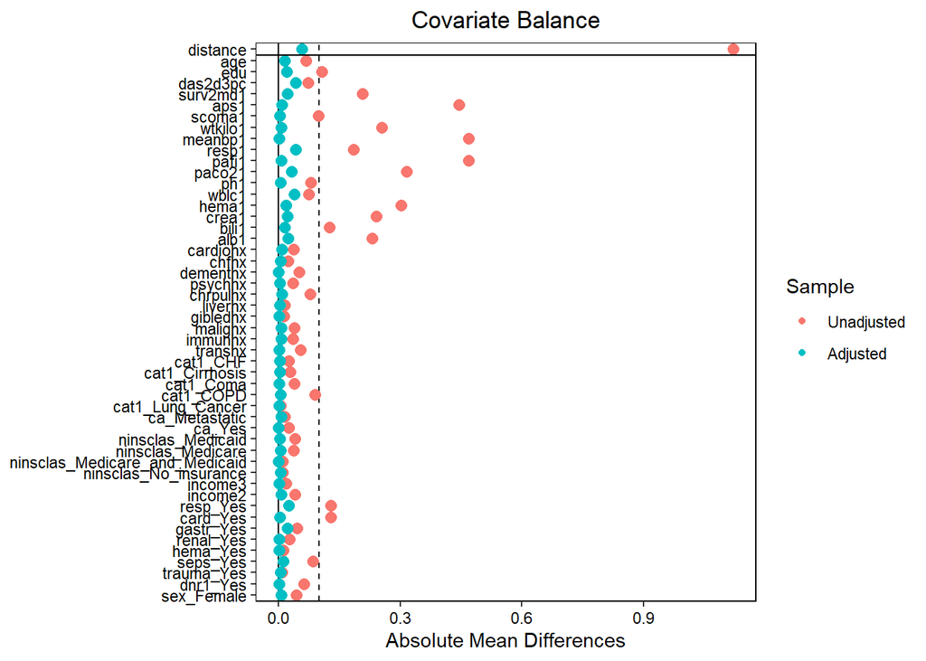

```r
# 4. Vérifier l'équilibre des covariables

library(cobalt)
love.plot(data_match, thresholds = c(m = .1), abs = TRUE)
```

```r
#5. extraire les données appariées

data_apparié <- match.data(data_match)
```

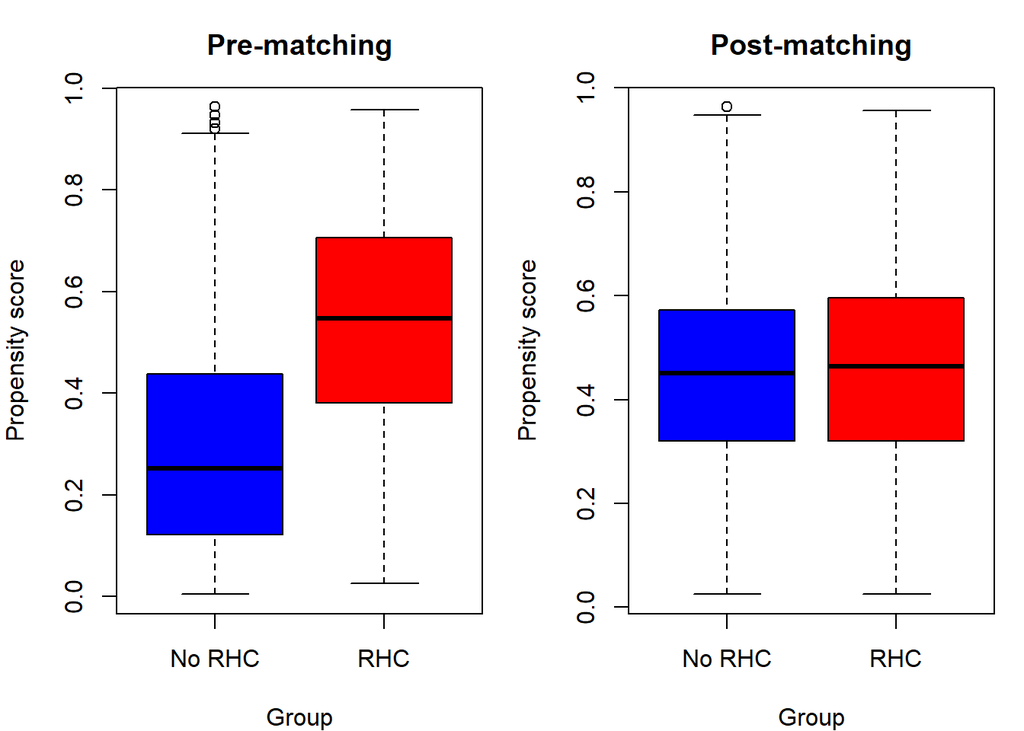

```r
# ====================================================
# POST-MATCHING DISTRIBUTION ASSESSMENT
# ====================================================
par(mfrow = c(1, 2), mar = c(4, 4, 3, 1))


# 2. Pre-matching boxplot (on data_complete)
# -------------------------------------------
boxplot(score ~ RHC, data = data_complete,
        col = c("blue", "red"),
        names = c("No RHC", "RHC"),
        main = "Pre-matching",
        xlab = "Group",
        ylab = "Propensity score")

# 2. Post-matching boxplot
# -------------------------
boxplot(score ~ RHC, data = data_apparié,
        col = c("blue", "red"),
        names = c("No RHC", "RHC"),
        main = "Post-matching",
        xlab = "Group",
        ylab = "Propensity score")
```

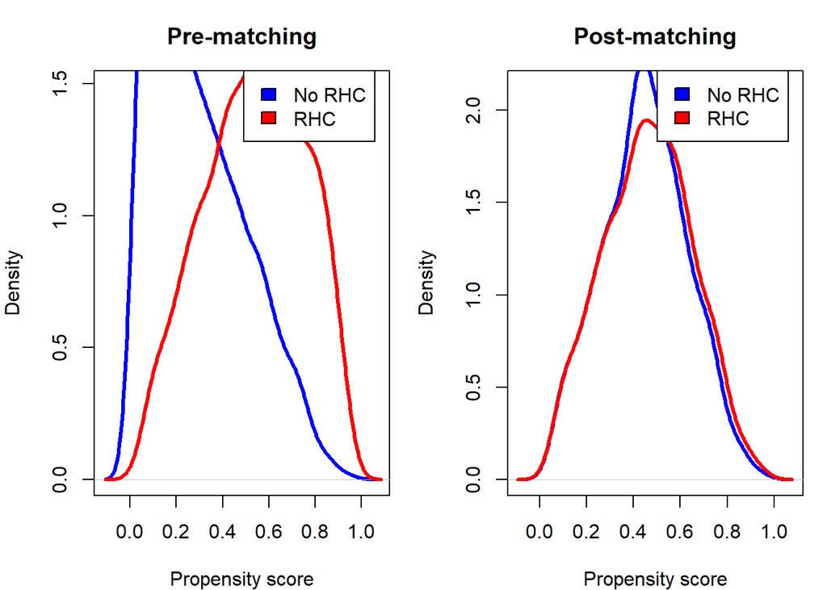

```r
par(mfrow = c(1, 2), mar = c(4, 4, 3, 1))

# 1. Pre-matching distribution (on data_complete)
# ------------------------------------------------
plot(density(data_complete$score[data_complete$RHC == 0], na.rm = TRUE),
     main = "Pre-matching",
     ylab = "Density",
     xlab = "Propensity score",
     col = "blue",
     lwd = 3,
     ylim = c(0, max(density(data_complete$score, na.rm = TRUE)$y)))

lines(density(data_complete$score[data_complete$RHC == 1], na.rm = TRUE),
      col = "red", lwd = 3)

legend("topright",
       legend = c("No RHC", "RHC"),
       fill = c("blue", "red"),
       inset = c(0.05, 0))


# 1. Post-matching distribution (on data_apparié)

# Tracer la distribution
plot(density(data_apparié$score[data_apparié$RHC == 0], na.rm = TRUE),
     main = "Post-matching",
     ylab = "Density",
     xlab = "Propensity score",
     col = "blue",
     lwd = 3,
     ylim = c(0, max(density(data_apparié$score, na.rm = TRUE)$y)))

lines(density(data_apparié$score[data_apparié$RHC == 1], na.rm = TRUE),
      col = "red", lwd = 3)

legend("topright",
       legend = c("No RHC", "RHC"),
       fill = c("blue", "red"),
       inset = c(0.05, 0))
```

# **Results**

```r
library(survival)
data_apparié$survival <- as.numeric(data_apparié$survival)


# 6. Modèle logistique conditionnel (sur les paires)
mod_final <- clogit(survival ~ RHC + strata(subclass),
                    data = data_apparié)

# 3. Résultats (Odds Ratio)
summary(mod_final)
```

```
## Call:
## coxph(formula = Surv(1 + 0 * survival, survival) ~ RHC + strata(subclass),
##     data = data_apparié, method = "exact")
##
##   n= 2918, number of events= 1019
##
##          coef exp(coef) se(coef)      z Pr(>|z|)
## RHC1 -0.19799   0.82038  0.07713 -2.567   0.0103 *
## ---
## Signif. codes:  0 '***' 0.001 '**' 0.01 '*' 0.05 '.' 0.1 ' ' 1
##
##      exp(coef) exp(-coef) lower .95 upper .95
## RHC1    0.8204      1.219    0.7053    0.9543
##
## Concordance= 0.549  (se = 0.027 )
## Likelihood ratio test= 6.62  on 1 df,   p=0.01
## Wald test            = 6.59  on 1 df,   p=0.01
## Score (logrank) test = 6.61  on 1 df,   p=0.01
```

```r
exp(cbind(OR = coef(mod_final), confint(mod_final)))
```

```
##             OR     2.5 %    97.5 %
## RHC1 0.8203753 0.7052774 0.9542567
```

# **Conclusion**